# Project Thera Bank

Lim Su Ping

3/5/2020

You are brought in as a consultant and your job is to build the best model which can classify the right customers who have a higher probability of purchasing the loan. You are expected to do the following: • EDA of the data available. Showcase the results using appropriate graphs • Apply appropriate clustering on the data and interpret the output (Thera Bank wants to understand what kind of customers exist in their database and hence we need to do customer segmentation) • Build appropriate models on both the test and train data (CART & Random Forest). Interpret all the model outputs and do the necessary modifications wherever eligible (such as pruning) • Check the performance of all the models that you have built (test and train). Use all the model performance measures you have learned so far. Share your remarks on which model performs the best

```r
# observe and clean data
# Check summary and structure of data
dim(datathera)
```

```
## [1] 5000   14
```

```r
head(datathera)
```

```
## # A tibble: 6 x 14
##      ID `Age (in years)` `Experience (in~ `Income (in K/m~ `ZIP Code`
##   <dbl>            <dbl>            <dbl>            <dbl>      <dbl>
## 1     1               25                1               49      91107
## 2     2               45               19               34      90089
## 3     3               39               15               11      94720
## 4     4               35                9              100      94112
## 5     5               35                8               45      91330
## 6     6               37               13               29      92121
## # ... with 9 more variables: `Family members` <dbl>, CCAvg <dbl>,
## #   Education <dbl>, Mortgage <dbl>, `Personal Loan` <dbl>, `Securities
## #   Account` <dbl>, `CD Account` <dbl>, Online <dbl>, CreditCard <dbl>
```

```r
str(datathera)
```

```
## Classes 'tbl_df', 'tbl' and 'data.frame':    5000 obs. of  14 variables:
##  $ ID                   : num  1 2 3 4 5 6 7 8 9 10 ...
##  $ Age (in years)       : num  25 45 39 35 35 37 53 50 35 34 ...
##  $ Experience (in years): num  1 19 15 9 8 13 27 24 10 9 ...
##  $ Income (in K/month)  : num  49 34 11 100 45 29 72 22 81 180 ...
##  $ ZIP Code             : num  91107 90089 94720 94112 91330 ...
##  $ Family members       : num  4 3 1 1 4 4 2 1 3 1 ...
##  $ CCAvg                : num  1.6 1.5 1 2.7 1 0.4 1.5 0.3 0.6 8.9 ...
##  $ Education            : num  1 1 1 2 2 2 2 3 2 3 ...
##  $ Mortgage             : num  0 0 0 0 0 155 0 0 104 0 ...
##  $ Personal Loan        : num  0 0 0 0 0 0 0 0 0 1 ...
##  $ Securities Account   : num  1 1 0 0 0 0 0 0 0 0 ...
##  $ CD Account           : num  0 0 0 0 0 0 0 0 0 0 ...
##  $ Online               : num  0 0 0 0 0 1 1 0 1 0 ...
##  $ CreditCard           : num  0 0 0 0 1 0 0 1 0 0 ...
```

```r
summary(datathera)
```

```
##        ID       Age (in years)  Experience (in years) Income (in K/month)
##  Min.   :   1   Min.   :23.00   Min.   :-3.0          Min.   :  8.00
##  1st Qu.:1251   1st Qu.:35.00   1st Qu.:10.0          1st Qu.: 39.00
##  Median :2500   Median :45.00   Median :20.0          Median : 64.00
##  Mean   :2500   Mean   :45.34   Mean   :20.1          Mean   : 73.77
##  3rd Qu.:3750   3rd Qu.:55.00   3rd Qu.:30.0          3rd Qu.: 98.00
##  Max.   :5000   Max.   :67.00   Max.   :43.0          Max.   :224.00
##
##     ZIP Code     Family members      CCAvg          Education
##  Min.   : 9307   Min.   :1.000   Min.   : 0.000   Min.   :1.000
##  1st Qu.:91911   1st Qu.:1.000   1st Qu.: 0.700   1st Qu.:1.000
##  Median :93437   Median :2.000   Median : 1.500   Median :2.000
##  Mean   :93153   Mean   :2.397   Mean   : 1.938   Mean   :1.881
##  3rd Qu.:94608   3rd Qu.:3.000   3rd Qu.: 2.500   3rd Qu.:3.000
##  Max.   :96651   Max.   :4.000   Max.   :10.000   Max.   :3.000
##                  NA's   :18
##     Mortgage     Personal Loan   Securities Account   CD Account
##  Min.   :  0.0   Min.   :0.000   Min.   :0.0000     Min.   :0.0000
##  1st Qu.:  0.0   1st Qu.:0.000   1st Qu.:0.0000     1st Qu.:0.0000
##  Median :  0.0   Median :0.000   Median :0.0000     Median :0.0000
##  Mean   : 56.5   Mean   :0.096   Mean   :0.1044     Mean   :0.0604
##  3rd Qu.:101.0   3rd Qu.:0.000   3rd Qu.:0.0000     3rd Qu.:0.0000
##  Max.   :635.0   Max.   :1.000   Max.   :1.0000     Max.   :1.0000
##
##      Online         CreditCard
##  Min.   :0.0000   Min.   :0.000
##  1st Qu.:0.0000   1st Qu.:0.000
##  Median :1.0000   Median :0.000
##  Mean   :0.5968   Mean   :0.294
##  3rd Qu.:1.0000   3rd Qu.:1.000
##  Max.   :1.0000   Max.   :1.000
##
```

```r
# Rename Columns
colnames(datathera) = make.names(colnames(datathera))
thera <- datathera %>% rename( Age = Age..in.years., Experience = Experience..in.years., Income = Income..in.K.month.)
colnames(thera)
```

```
##  [1] "ID"                 "Age"                "Experience"
##  [4] "Income"             "ZIP.Code"           "Family.members"
##  [7] "CCAvg"              "Education"          "Mortgage"
## [10] "Personal.Loan"      "Securities.Account" "CD.Account"
## [13] "Online"             "CreditCard"
```

```r
View(thera)
```

### Exploratory Data Analysis

The Thera Bank dataset has 5000 rows of observations and 14 variables. Checking through the data, the columns are first renamed for ease of working with the data.

There are missing Data for the Family.members variable, as well as negative values for Experience. Missing NA data for 18 entries in Family members are treated as “0”, instead of setting it to median or mean, since it is possible that there may be instances where an individual may be living alone. At the same time, this allows for the 18 observed rows to be included in the analysis. Experience values are also treated as absolute values, which makes more sense within the context of the data.

There is also one ZIP code which is 4 digit instead of 5, but seeing as it is just 1 entry it will not be significant and no changes will be made

```r
# Determine if there are any NA data within, locate where NAs are
anyNA(thera)
```

```
## [1] TRUE
```

```r
colSums(is.na(thera))
```

```
##                 ID                Age         Experience             Income
##                  0                  0                  0                  0
##           ZIP.Code     Family.members              CCAvg          Education
##                  0                 18                  0                  0
##           Mortgage      Personal.Loan Securities.Account         CD.Account
##                  0                  0                  0                  0
##             Online         CreditCard
##                  0                  0
```

```r
# replace NA with "0"
thera[is.na(thera)] = 0

summary(thera$Family.members) #check
```

```
##    Min. 1st Qu.  Median    Mean 3rd Qu.    Max.
##   0.000   1.000   2.000   2.389   3.000   4.000
```

```r
# Manage negative values for Experience variable
thera$Experience = abs(thera$Experience)
summary(thera$Experience) #check
```

```
##    Min. 1st Qu.  Median    Mean 3rd Qu.    Max.
##    0.00   10.00   20.00   20.13   30.00   43.00
```

Screening through the rest of the data, it is observed that the following variables serve no purpose to the analysis and will be removed for analysis: ID

ZIPcode is also expressed as a factor to see which areas are significant.

```r
#Set as factors
thera$Education = as.factor(thera$Education)
thera$Personal.Loan = as.factor(thera$Personal.Loan)
thera$Securities.Account = as.factor(thera$Securities.Account)
thera$CD.Account = as.factor(thera$CD.Account)
thera$Online = as.factor(thera$Online)
thera$CreditCard = as.factor(thera$CreditCard)
thera$ZIP.Code = as.factor(thera$ZIP.Code)

# subset - remove ID and ZIP code variables

theradata <- thera[, -c(1)]
summary(theradata) #check
```

```
##       Age          Experience        Income          ZIP.Code
##  Min.   :23.00   Min.   : 0.00   Min.   :  8.00   94720  : 169
##  1st Qu.:35.00   1st Qu.:10.00   1st Qu.: 39.00   94305  : 127
##  Median :45.00   Median :20.00   Median : 64.00   95616  : 116
##  Mean   :45.34   Mean   :20.13   Mean   : 73.77   90095  :  71
##  3rd Qu.:55.00   3rd Qu.:30.00   3rd Qu.: 98.00   93106  :  57
##  Max.   :67.00   Max.   :43.00   Max.   :224.00   92037  :  54
##                                                   (Other):4406
##  Family.members      CCAvg        Education    Mortgage     Personal.Loan
##  Min.   :0.000   Min.   : 0.000   1:2096    Min.   :  0.0   0:4520
##  1st Qu.:1.000   1st Qu.: 0.700   2:1403    1st Qu.:  0.0   1: 480
##  Median :2.000   Median : 1.500   3:1501    Median :  0.0
##  Mean   :2.389   Mean   : 1.938             Mean   : 56.5
##  3rd Qu.:3.000   3rd Qu.: 2.500             3rd Qu.:101.0
##  Max.   :4.000   Max.   :10.000             Max.   :635.0
##
##  Securities.Account CD.Account Online   CreditCard
##  0:4478             0:4698     0:2016   0:3530
##  1: 522             1: 302     1:2984   1:1470
##
##
##
##
##
```

```r
# Education ordered factors
thera$Education = factor(thera$Education, order = TRUE)
summary(thera$Education)
```

```
##    1    2    3
## 2096 1403 1501
```

### Univariate Analysis

All continuous and factored variables are plotted to observe the data of Thera Bank customers and their relationships with the bank.

```r
# proportion of customers who took a personal loan after the recent campaign
prop.table(table(theradata$Personal.Loan))*100
```

```
##
##    0    1
## 90.4  9.6
```

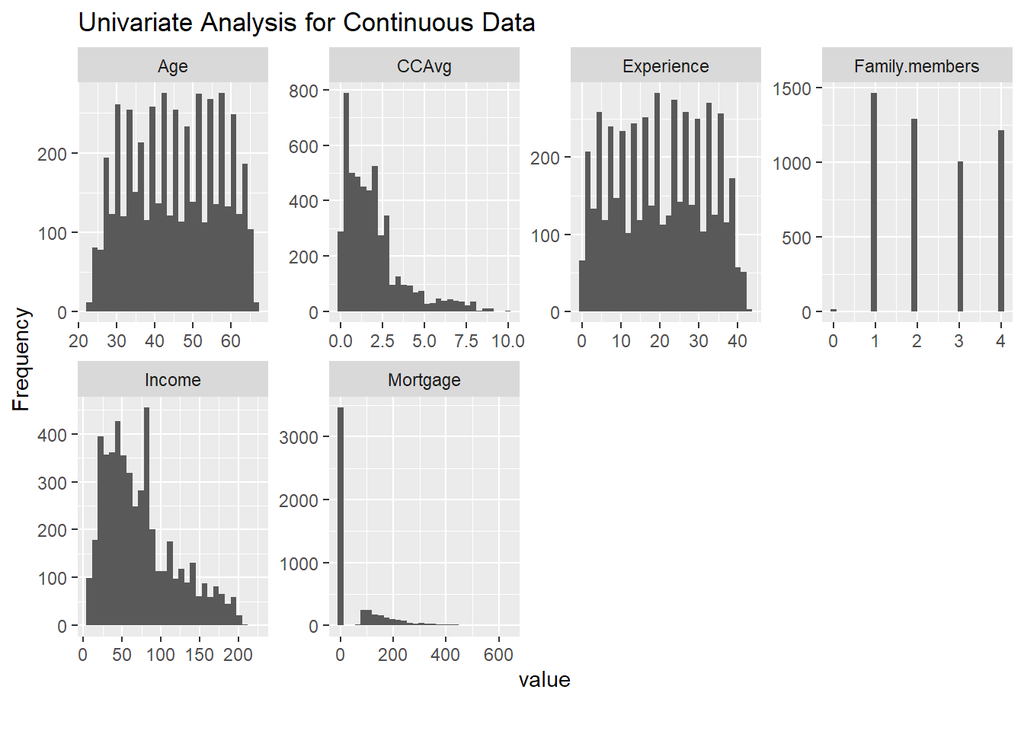

```r
plot_histogram(theradata, title ="Univariate Analysis for Continuous Data")
```

```
## 1 columns ignored with more than 50 categories.
## ZIP.Code: 467 categories
```

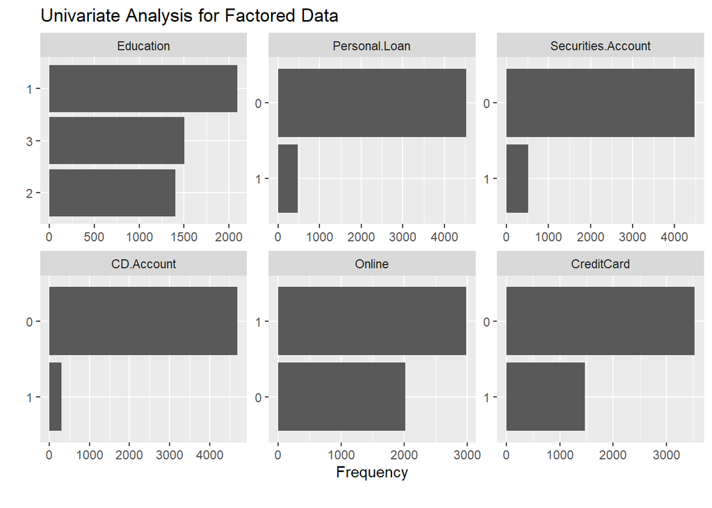

```r
plot_bar(theradata, title ="Univariate Analysis for Factored Data")
```

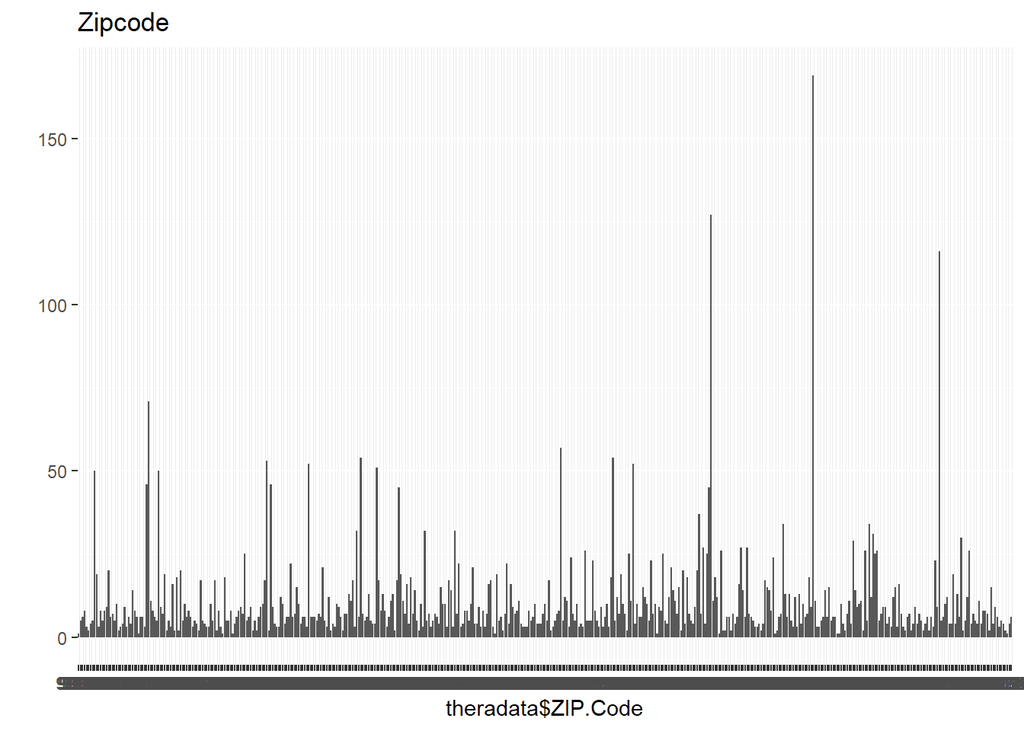

```r
#plot for Zipcode to observe frequency
qplot(theradata$ZIP.Code, main = "Zipcode")
```

```r
table(theradata$ZIP.Code, theradata$Personal.Loan=="1")
```

```
##
##         FALSE TRUE
##   9307      1    0
##   90005     5    0
##   90007     6    0
##   90009     8    0
##   90011     3    0
##   90016     1    1
##   90018     4    0
##   90019     4    1
##   90024    49    1
##   90025    17    2
##   90027     2    1
##   90028     7    1
##   90029     5    0
```

[output cut: 454 more lines]

```r
# Top 10% of customers from the following Zipcodes - 94720, 94305, 95616, 90095, 93106
```